# Lab 1

# 6 Loops

Sometimes, we need to iterate an action over many elements (e.g., rows or columns of a dataset, elements of a list, levels of a variable, etc.). One straightforward way to do that is with a **for loop**.

To make a for loop, we need a few components:

- A sequence of numbers, objects, or characters that we want to iterate over
- A set of actions to perform
- An output
- An optional place to store this output

```r
#print the numbers 1-10
for (i in 1:10){
  print(i)
}
#note that these only show up in the console since we didn't save them anywhere

for_loop_output <- NULL #create a blank object to store our output in
#fill elements 1-10 of this object with the numbers 1-10
for(i in 1:10){
  for_loop_output[i] <- i
}
for_loop_output

#make new columns in our dataset, by filling them out one row at a time
for(i in 1:nrow(df)){
  df$fun_new_col[i] <- i
  df$other_fun_col[i] <- df$flipper_length_mm[i]/df$body_mass_g[i]
}
```

Let’s try something a little more complicated: a loop within a loop! Let’s say we want to find the mean body mass of each penguin species on each island. We’ll provide you the code for the mean mass for each species across islands, and it’ll be your job to try to make a loop within a loop to split these mean masses up by island:

```r
mass_means <- NULL
counter <- 1
for(i in unique(df$species)){
    mass_means[counter] <- mean(df$body_mass_g[df$species==i],na.rm=TRUE)
    names(mass_means)[counter] <- i
    counter <- counter + 1
}
```

In some cases, doing complex looping like this is necessary, so it’s important to learn! But for doing simple calculations like means on different groups, there are often a lot of great functions that already exist. For instance we could have done this instead:

```r
mass_means2 <- df %>%
  group_by(species, island) %>% #group_by tells R that we want all the following steps done individually on each group
  summarize(mean = mean(body_mass_g, na.rm=TRUE)) %>% #summarize creates a new column in our data frame that does the calculation we specify
  ungroup() #this line isn't necessary here, but is good practice to run after a group_by() line in case you do any further operations on this data frame
```

# 7 Custom functions

Finally, to be able to code effectively, we need to learn how to make our own functions! When we create our own functions, we’re essentially building a recipe for R to follow to do something useful. If you have to copy and paste chunks of your code more than a couple times, it’s probably a good idea to make a function for yourself instead. This is because if you copy and paste your code a bunch but make a change to one chunk, you’re likely to forget to make the same changes in every other chunk. Whereas if you have your code written as a function, you only need to make the change once!

To make a function, we need a few components:

- A name that we assign to the function
- A list of arguments that we need to feed into the function for it to be able to run (e.g., if we want to apply our function to a column of a data frame, we need to define both the data frame and the column name in the arguments section)
- A series of steps for the function to follow
- An output (note that if you don’t specify this, custom functions will always return the result from the last line of code within it)

Let’s say we want to plot a histogram of a log-transformed column of our data:

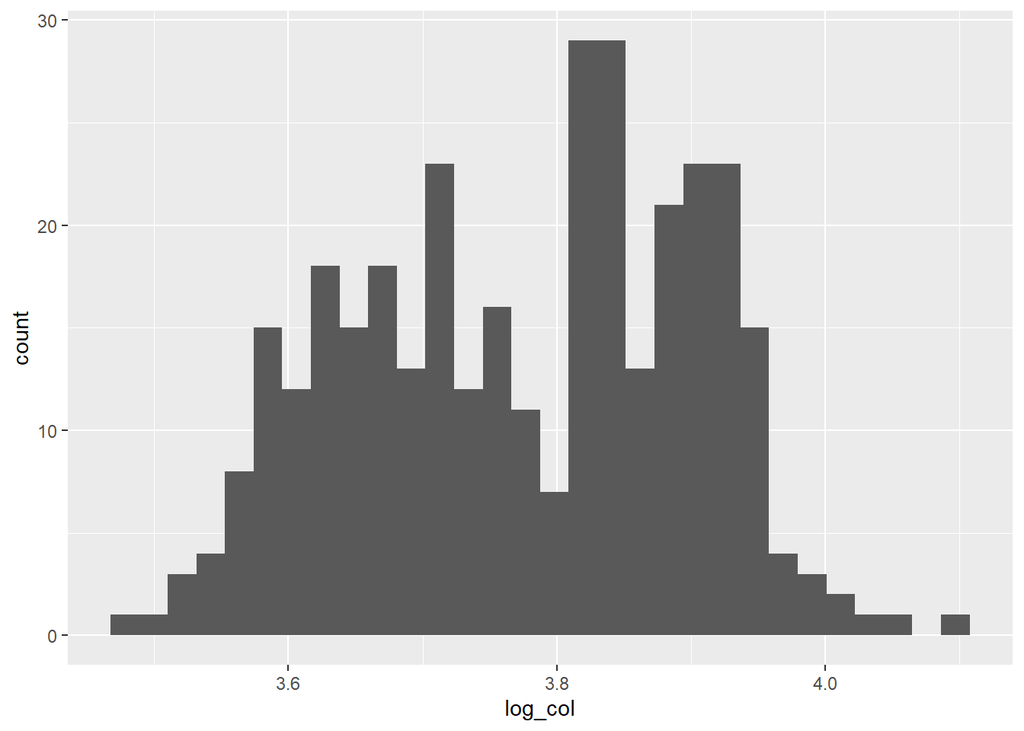

```r
custom_function <- function(data, column){
  data$log_col <- log(data[[column]])
  ggplot(data, aes(x = log_col)) +
    geom_histogram()
}

custom_function(data = df, column = 'bill_length_mm')
```

If we wanted to run this function on multiple columns we have a few options for how to do this! We could copy and paste it, we could run a for loop, or we could use an “apply” statement to apply it to multiple arguments:

```r
#copy paste
custom_function(data = df, column = 'bill_length_mm')
custom_function(data = df, column = 'bill_depth_mm')
custom_function(data = df, column = 'flipper_length_mm')

#for loop
cols <- c("bill_length_mm", "bill_depth_mm", "flipper_length_mm")
custom_output_loop <- NULL
for(i in 1:length(cols)){
  custom_output_loop[[i]] <- custom_function(data = df, column = cols[i])
}

#access the output by specifying which plot you want
custom_output_loop[[1]]
#or all of them:
custom_output_loop

#apply statement
cols <- c("bill_length_mm","bill_depth_mm", "flipper_length_mm")
custom_output_apply <- lapply(X = cols, FUN = custom_function, data = df)
#note that since our function has two arguments, we specify which one we're
#applying the function across with 'X' and any of the arguments that stay
#constant with their argument names from our custom function

#access the output by specifying which plot you want
custom_output_apply[[1]]
#or all of them:
custom_output_apply
```

**Hot tip: functions can only recognize arguments that you put between the parentheses!** Even if you have an object in your environment with the name of an argument that is in your function, your function won’t know that this is the object you want it to use unless you explicitly tell it.

In our example from above, even if we had written `custom_function()` with the argument `df` instead of `data`, we would still have to specify that `df = df` in the function - R wouldn’t know to use our object named `df` automatically.